# Lab 2 Assignment

Dhananjay

2023-02-06

## Q1. Getting and Reformatting Data

The US Census website provides a data set representing many population statistics from 2010 to 2014 at the following website:

[Census Pop Stats](https://www2.census.gov/programs-surveys/popest/datasets/2010-2014/state/asrh/)

These data sets can be downloaded as a CSV that is readable directly in R. Load the “sc-est2014-agesex-civ.csv” set. Select the subset of the data corresponding to the variables POPEST2010_CIV through POPEST2014_CIV for Florida and Alabama (hint: filter, slice, subset), then reformat that data so it easier to visualize (hint: melt), and finally provide a line plot with two trends showing the number of births over all the years in the 2010-2014 period for Florida and Alabama.

```r
# Loading the required library
library(tidyverse)
library(reshape)
library(reshape2)
```

```r
library(ggplot2)

# Reading the data
censusData <-  read.csv("sc-est2014-agesex-civ.csv", header = TRUE, sep = ',')
# summary(censusData)
# head(censusData)

# Filtering the data for Florida (FL) and Alabama (AL) state
# Alabama denoted by STATE = 1 and Florida denoted by STATE = 12 in the dataset

# filteredCensusData <- filter(censusData, NAME == c("Alabama", "Florida"))
filteredCensusData <- censusData[censusData$NAME %in% c("Florida", "Alabama"), ]
# print(filteredCensusData)

# Focus is on the number of births (implies AGE = 0) in the dataset

birthCensusData <- filter(filteredCensusData, AGE == 0)
print(birthCensusData)
```

```
##   SUMLEV REGION DIVISION STATE    NAME SEX AGE ESTBASE2010_CIV POPEST2010_CIV
## 1     40      3        6     1 Alabama   0   0           60056          60026
## 2     40      3        6     1 Alabama   1   0           30465          30565
## 3     40      3        6     1 Alabama   2   0           29591          29461
## 4     40      3        5    12 Florida   0   0          208724         210560
## 5     40      3        5    12 Florida   1   0          106269         107328
## 6     40      3        5    12 Florida   2   0          102455         103232
##   POPEST2011_CIV POPEST2012_CIV POPEST2013_CIV POPEST2014_CIV
## 1          59219          58621          57651          57854
## 2          30427          29734          29279          29508
## 3          28792          28887          28372          28346
## 4         213792         214764         213888         215254
## 5         109464         109790         109307         109916
## 6         104328         104974         104581         105338
```

```r
# SEX = 0 denotes Total (Male + Female), SEX = 1 (Male), SEX = 2 (Female) in the dataset
# Selecting the data where AGE = 0 and SEX = 0 gives the no of births in a year for a specific state

totalBirthCensusData <- birthCensusData[birthCensusData$AGE == 0 & birthCensusData$SEX == 0, ]
print(totalBirthCensusData)
```

```
##   SUMLEV REGION DIVISION STATE    NAME SEX AGE ESTBASE2010_CIV POPEST2010_CIV
## 1     40      3        6     1 Alabama   0   0           60056          60026
## 4     40      3        5    12 Florida   0   0          208724         210560
##   POPEST2011_CIV POPEST2012_CIV POPEST2013_CIV POPEST2014_CIV
## 1          59219          58621          57651          57854
## 4         213792         214764         213888         215254
```

```r
# Selecting subset of data corresponding to variables POPEST2010_CIV through POPEST2014_CIV
subsetBirthCensusData <- totalBirthCensusData[, c("NAME", "POPEST2010_CIV", "POPEST2011_CIV", "POPEST2012_CIV", "POPEST2013_CIV", "POPEST2014_CIV")]
print(subsetBirthCensusData)
```

```
##      NAME POPEST2010_CIV POPEST2011_CIV POPEST2012_CIV POPEST2013_CIV
## 1 Alabama          60026          59219          58621          57651
## 4 Florida         210560         213792         214764         213888
##   POPEST2014_CIV
## 1          57854
## 4         215254
```

```r
# head(subsetBirthCensusData)

# Reformatting the data for easier visualization
reformattedBirthData <- melt(subsetBirthCensusData, na.rm = FALSE, id = "NAME")

# Renaming the column names
names(reformattedBirthData) <- c("State", "Year", "Population")

# Displaying the reformatted data
print(reformattedBirthData)
```

```
##      State           Year Population
## 1  Alabama POPEST2010_CIV      60026
## 2  Florida POPEST2010_CIV     210560
## 3  Alabama POPEST2011_CIV      59219
## 4  Florida POPEST2011_CIV     213792
## 5  Alabama POPEST2012_CIV      58621
## 6  Florida POPEST2012_CIV     214764
## 7  Alabama POPEST2013_CIV      57651
## 8  Florida POPEST2013_CIV     213888
## 9  Alabama POPEST2014_CIV      57854
## 10 Florida POPEST2014_CIV     215254
```

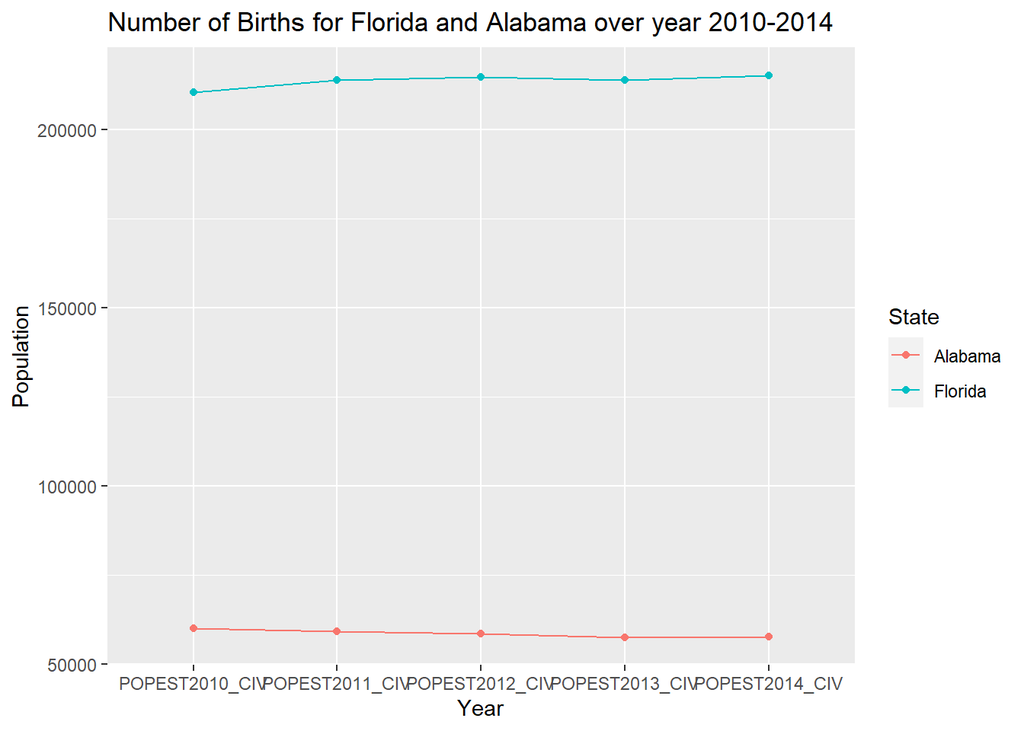

```r
# Plotting the data
ggplot(reformattedBirthData, aes(x = Year, y = Population, color = State)) +
  geom_line(aes(group = State)) +
  geom_point() +
  #coord_flip() +
  xlab("Year") +
  ylab("Population") +
  ggtitle("Number of Births for Florida and Alabama over year 2010-2014")
```

Compare this to more recent data [sc-est2021-agesex-civ.csv](https://www2.census.gov/programs-surveys/popest/datasets/2020-2021/state/asrh/)

Pick the most recent year, and plot all the states - highlight FL. (Show this plot 2 different ways - compare and contrast which is the best way to display the data.)

Answer: The plot generated is a bar chart. This plot will be shown in two different ways i.e, horizonatlly and vertically.

The first plot shows the vertical bar chart.

```
##     SUMLEV REGION DIVISION STATE                 NAME SEX AGE ESTBASE2010_CIV
## 1       40      3        6     1              Alabama   0   0           60056
## 2       40      3        6     1              Alabama   1   0           30465
## 3       40      3        6     1              Alabama   2   0           29591
## 4       40      4        9     2               Alaska   0   0           10828
## 5       40      4        9     2               Alaska   1   0            5590
## 6       40      4        9     2               Alaska   2   0            5238
## 7       40      4        8     4              Arizona   0   0           87557
## 8       40      4        8     4              Arizona   1   0           44652
## 9       40      4        8     4              Arizona   2   0           42905
## 10      40      3        7     5             Arkansas   0   0           38402
## 11      40      3        7     5             Arkansas   1   0           19735
## 12      40      3        7     5             Arkansas   2   0           18667
## 13      40      4        9     6           California   0   0          494058
## 14      40      4        9     6           California   1   0          252121
```

[output cut: 293 more lines]

```
##     SUMLEV REGION DIVISION STATE                 NAME SEX AGE ESTBASE2010_CIV
## 1       40      3        6     1              Alabama   0   0           60056
## 4       40      4        9     2               Alaska   0   0           10828
## 7       40      4        8     4              Arizona   0   0           87557
## 10      40      3        7     5             Arkansas   0   0           38402
## 13      40      4        9     6           California   0   0          494058
## 16      40      4        8     8             Colorado   0   0           66594
## 19      40      1        1     9          Connecticut   0   0           38012
## 22      40      3        5    10             Delaware   0   0           10858
## 25      40      3        5    11 District of Columbia   0   0            7156
## 28      40      3        5    12              Florida   0   0          208724
## 31      40      3        5    13              Georgia   0   0          133182
## 34      40      4        9    15               Hawaii   0   0           17764
## 37      40      4        8    16                Idaho   0   0           23610
## 40      40      2        3    17             Illinois   0   0          162506
```

[output cut: 89 more lines]

```
##                     NAME POPEST2013_CIV POPEST2014_CIV
## 1                Alabama          57651          57854
## 4                 Alaska          11199          11157
## 7                Arizona          85949          85876
## 10              Arkansas          38052          37936
## 13            California         502983         502993
## 16              Colorado          65835          66471
## 19           Connecticut          36597          36771
## 22              Delaware          10995          11122
## 25  District of Columbia           9197           9147
## 28               Florida         213888         215254
## 31               Georgia         129036         129104
## 34                Hawaii          18658          18853
## 37                 Idaho          22744          22805
## 40              Illinois         156692         156134
```

[output cut: 37 more lines]

```
##     SUMLEV REGION DIVISION STATE                 NAME SEX AGE ESTBASE2020_CIV
## 1       40      3        6     1              Alabama   0   0           57105
## 2       40      3        6     1              Alabama   1   0           29173
## 3       40      3        6     1              Alabama   2   0           27932
## 4       40      4        9     2               Alaska   0   0            9657
## 5       40      4        9     2               Alaska   1   0            4941
## 6       40      4        9     2               Alaska   2   0            4716
## 7       40      4        8     4              Arizona   0   0           78100
## 8       40      4        8     4              Arizona   1   0           39928
## 9       40      4        8     4              Arizona   2   0           38172
## 10      40      3        7     5             Arkansas   0   0           35611
## 11      40      3        7     5             Arkansas   1   0           18209
## 12      40      3        7     5             Arkansas   2   0           17402
## 13      40      4        9     6           California   0   0          445470
## 14      40      4        9     6           California   1   0          227711
```

[output cut: 293 more lines]

```
##     SUMLEV REGION DIVISION STATE                 NAME SEX AGE ESTBASE2020_CIV
## 1       40      3        6     1              Alabama   0   0           57105
## 4       40      4        9     2               Alaska   0   0            9657
## 7       40      4        8     4              Arizona   0   0           78100
## 10      40      3        7     5             Arkansas   0   0           35611
## 13      40      4        9     6           California   0   0          445470
## 16      40      4        8     8             Colorado   0   0           62235
## 19      40      1        1     9          Connecticut   0   0           34477
## 22      40      3        5    10             Delaware   0   0           10482
## 25      40      3        5    11 District of Columbia   0   0            8886
## 28      40      3        5    12              Florida   0   0          216820
## 31      40      3        5    13              Georgia   0   0          124074
## 34      40      4        9    15               Hawaii   0   0           16714
## 37      40      4        8    16                Idaho   0   0           21581
## 40      40      2        3    17             Illinois   0   0          141497
```

[output cut: 89 more lines]

```
##                     NAME POPEST2021_CIV
## 1                Alabama          55812
## 4                 Alaska           9236
## 7                Arizona          76130
## 10              Arkansas          34720
## 13            California         422861
## 16              Colorado          60341
## 19           Connecticut          32573
## 22              Delaware          10280
## 25  District of Columbia           8771
## 28               Florida         209420
## 31               Georgia         120296
## 34                Hawaii          15810
## 37                 Idaho          21203
## 40              Illinois         132242
```

[output cut: 37 more lines]

```
##                   State           Year Population
## 1               Alabama POPEST2021_CIV      55812
## 2                Alaska POPEST2021_CIV       9236
## 3               Arizona POPEST2021_CIV      76130
## 4              Arkansas POPEST2021_CIV      34720
## 5            California POPEST2021_CIV     422861
## 6              Colorado POPEST2021_CIV      60341
## 7           Connecticut POPEST2021_CIV      32573
## 8              Delaware POPEST2021_CIV      10280
## 9  District of Columbia POPEST2021_CIV       8771
## 10              Florida POPEST2021_CIV     209420
## 11              Georgia POPEST2021_CIV     120296
## 12               Hawaii POPEST2021_CIV      15810
## 13                Idaho POPEST2021_CIV      21203
## 14             Illinois POPEST2021_CIV     132242
```

[output cut: 37 more lines]

```
##                    NAME POPEST2013_CIV POPEST2014_CIV POPEST2021_CIV
## 1               Alabama          57651          57854          55812
## 2                Alaska          11199          11157           9236
## 3               Arizona          85949          85876          76130
## 4              Arkansas          38052          37936          34720
## 5            California         502983         502993         422861
## 6              Colorado          65835          66471          60341
## 7           Connecticut          36597          36771          32573
## 8              Delaware          10995          11122          10280
## 9  District of Columbia           9197           9147           8771
## 10              Florida         213888         215254         209420
## 11              Georgia         129036         129104         120296
## 12               Hawaii          18658          18853          15810
## 13                Idaho          22744          22805          21203
## 14             Illinois         156692         156134         132242
```

[output cut: 37 more lines]

```
##                    State           Year Population
## 1                Alabama POPEST2013_CIV      57651
## 2                 Alaska POPEST2013_CIV      11199
## 3                Arizona POPEST2013_CIV      85949
## 4               Arkansas POPEST2013_CIV      38052
## 5             California POPEST2013_CIV     502983
## 6               Colorado POPEST2013_CIV      65835
## 7            Connecticut POPEST2013_CIV      36597
## 8               Delaware POPEST2013_CIV      10995
## 9   District of Columbia POPEST2013_CIV       9197
## 10               Florida POPEST2013_CIV     213888
## 11               Georgia POPEST2013_CIV     129036
## 12                Hawaii POPEST2013_CIV      18658
## 13                 Idaho POPEST2013_CIV      22744
## 14              Illinois POPEST2013_CIV     156692
```

[output cut: 139 more lines]

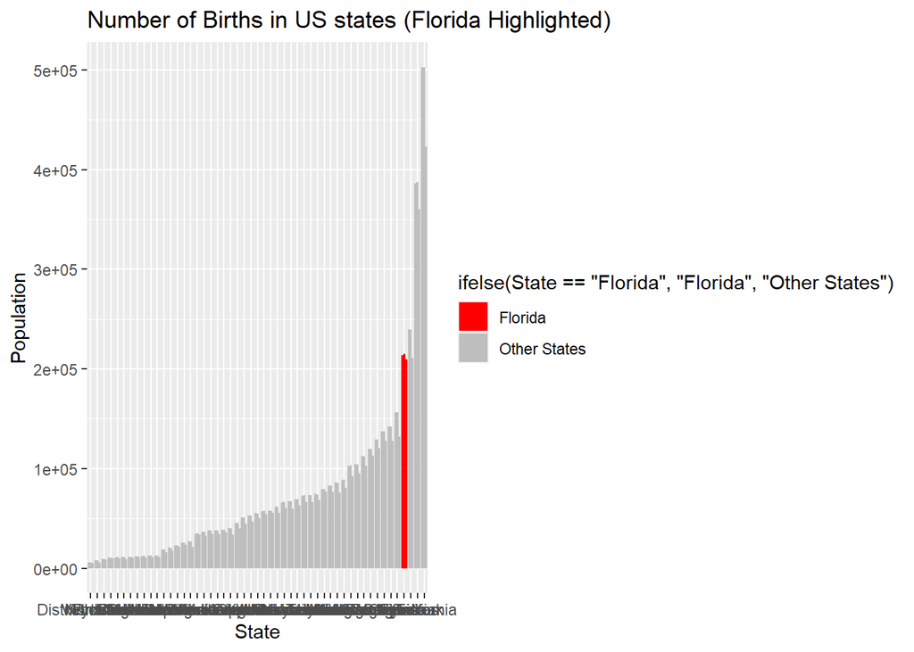

The second plot shows the horizontal bar chart.

```
##     SUMLEV REGION DIVISION STATE                 NAME SEX AGE ESTBASE2010_CIV
## 1       40      3        6     1              Alabama   0   0           60056
## 2       40      3        6     1              Alabama   1   0           30465
## 3       40      3        6     1              Alabama   2   0           29591
## 4       40      4        9     2               Alaska   0   0           10828
## 5       40      4        9     2               Alaska   1   0            5590
## 6       40      4        9     2               Alaska   2   0            5238
## 7       40      4        8     4              Arizona   0   0           87557
## 8       40      4        8     4              Arizona   1   0           44652
## 9       40      4        8     4              Arizona   2   0           42905
## 10      40      3        7     5             Arkansas   0   0           38402
## 11      40      3        7     5             Arkansas   1   0           19735
## 12      40      3        7     5             Arkansas   2   0           18667
## 13      40      4        9     6           California   0   0          494058
## 14      40      4        9     6           California   1   0          252121
```

[output cut: 293 more lines]

```
##     SUMLEV REGION DIVISION STATE                 NAME SEX AGE ESTBASE2010_CIV
## 1       40      3        6     1              Alabama   0   0           60056
## 4       40      4        9     2               Alaska   0   0           10828
## 7       40      4        8     4              Arizona   0   0           87557
## 10      40      3        7     5             Arkansas   0   0           38402
## 13      40      4        9     6           California   0   0          494058
## 16      40      4        8     8             Colorado   0   0           66594
## 19      40      1        1     9          Connecticut   0   0           38012
## 22      40      3        5    10             Delaware   0   0           10858
## 25      40      3        5    11 District of Columbia   0   0            7156
## 28      40      3        5    12              Florida   0   0          208724
## 31      40      3        5    13              Georgia   0   0          133182
## 34      40      4        9    15               Hawaii   0   0           17764
## 37      40      4        8    16                Idaho   0   0           23610
## 40      40      2        3    17             Illinois   0   0          162506
```

[output cut: 89 more lines]

```
##                     NAME POPEST2013_CIV POPEST2014_CIV
## 1                Alabama          57651          57854
## 4                 Alaska          11199          11157
## 7                Arizona          85949          85876
## 10              Arkansas          38052          37936
## 13            California         502983         502993
## 16              Colorado          65835          66471
## 19           Connecticut          36597          36771
## 22              Delaware          10995          11122
## 25  District of Columbia           9197           9147
## 28               Florida         213888         215254
## 31               Georgia         129036         129104
## 34                Hawaii          18658          18853
## 37                 Idaho          22744          22805
## 40              Illinois         156692         156134
```

[output cut: 37 more lines]

```
##     SUMLEV REGION DIVISION STATE                 NAME SEX AGE ESTBASE2020_CIV
## 1       40      3        6     1              Alabama   0   0           57105
## 2       40      3        6     1              Alabama   1   0           29173
## 3       40      3        6     1              Alabama   2   0           27932
## 4       40      4        9     2               Alaska   0   0            9657
## 5       40      4        9     2               Alaska   1   0            4941
## 6       40      4        9     2               Alaska   2   0            4716
## 7       40      4        8     4              Arizona   0   0           78100
## 8       40      4        8     4              Arizona   1   0           39928
## 9       40      4        8     4              Arizona   2   0           38172
## 10      40      3        7     5             Arkansas   0   0           35611
## 11      40      3        7     5             Arkansas   1   0           18209
## 12      40      3        7     5             Arkansas   2   0           17402
## 13      40      4        9     6           California   0   0          445470
## 14      40      4        9     6           California   1   0          227711
```

[output cut: 293 more lines]

```
##     SUMLEV REGION DIVISION STATE                 NAME SEX AGE ESTBASE2020_CIV
## 1       40      3        6     1              Alabama   0   0           57105
## 4       40      4        9     2               Alaska   0   0            9657
## 7       40      4        8     4              Arizona   0   0           78100
## 10      40      3        7     5             Arkansas   0   0           35611
## 13      40      4        9     6           California   0   0          445470
## 16      40      4        8     8             Colorado   0   0           62235
## 19      40      1        1     9          Connecticut   0   0           34477
## 22      40      3        5    10             Delaware   0   0           10482
## 25      40      3        5    11 District of Columbia   0   0            8886
## 28      40      3        5    12              Florida   0   0          216820
## 31      40      3        5    13              Georgia   0   0          124074
## 34      40      4        9    15               Hawaii   0   0           16714
## 37      40      4        8    16                Idaho   0   0           21581
## 40      40      2        3    17             Illinois   0   0          141497
```

[output cut: 89 more lines]

```
##                     NAME POPEST2021_CIV
## 1                Alabama          55812
## 4                 Alaska           9236
## 7                Arizona          76130
## 10              Arkansas          34720
## 13            California         422861
## 16              Colorado          60341
## 19           Connecticut          32573
## 22              Delaware          10280
## 25  District of Columbia           8771
## 28               Florida         209420
## 31               Georgia         120296
## 34                Hawaii          15810
## 37                 Idaho          21203
## 40              Illinois         132242
```

[output cut: 37 more lines]

```
##                   State           Year Population
## 1               Alabama POPEST2021_CIV      55812
## 2                Alaska POPEST2021_CIV       9236
## 3               Arizona POPEST2021_CIV      76130
## 4              Arkansas POPEST2021_CIV      34720
## 5            California POPEST2021_CIV     422861
## 6              Colorado POPEST2021_CIV      60341
## 7           Connecticut POPEST2021_CIV      32573
## 8              Delaware POPEST2021_CIV      10280
## 9  District of Columbia POPEST2021_CIV       8771
## 10              Florida POPEST2021_CIV     209420
## 11              Georgia POPEST2021_CIV     120296
## 12               Hawaii POPEST2021_CIV      15810
## 13                Idaho POPEST2021_CIV      21203
## 14             Illinois POPEST2021_CIV     132242
```

[output cut: 37 more lines]

```
##                    NAME POPEST2013_CIV POPEST2014_CIV POPEST2021_CIV
## 1               Alabama          57651          57854          55812
## 2                Alaska          11199          11157           9236
## 3               Arizona          85949          85876          76130
## 4              Arkansas          38052          37936          34720
## 5            California         502983         502993         422861
## 6              Colorado          65835          66471          60341
## 7           Connecticut          36597          36771          32573
## 8              Delaware          10995          11122          10280
## 9  District of Columbia           9197           9147           8771
## 10              Florida         213888         215254         209420
## 11              Georgia         129036         129104         120296
## 12               Hawaii          18658          18853          15810
## 13                Idaho          22744          22805          21203
## 14             Illinois         156692         156134         132242
```

[output cut: 37 more lines]

```
##                    State           Year Population
## 1                Alabama POPEST2013_CIV      57651
## 2                 Alaska POPEST2013_CIV      11199
## 3                Arizona POPEST2013_CIV      85949
## 4               Arkansas POPEST2013_CIV      38052
## 5             California POPEST2013_CIV     502983
## 6               Colorado POPEST2013_CIV      65835
## 7            Connecticut POPEST2013_CIV      36597
## 8               Delaware POPEST2013_CIV      10995
## 9   District of Columbia POPEST2013_CIV       9197
## 10               Florida POPEST2013_CIV     213888
## 11               Georgia POPEST2013_CIV     129036
## 12                Hawaii POPEST2013_CIV      18658
## 13                 Idaho POPEST2013_CIV      22744
## 14              Illinois POPEST2013_CIV     156692
```

[output cut: 139 more lines]

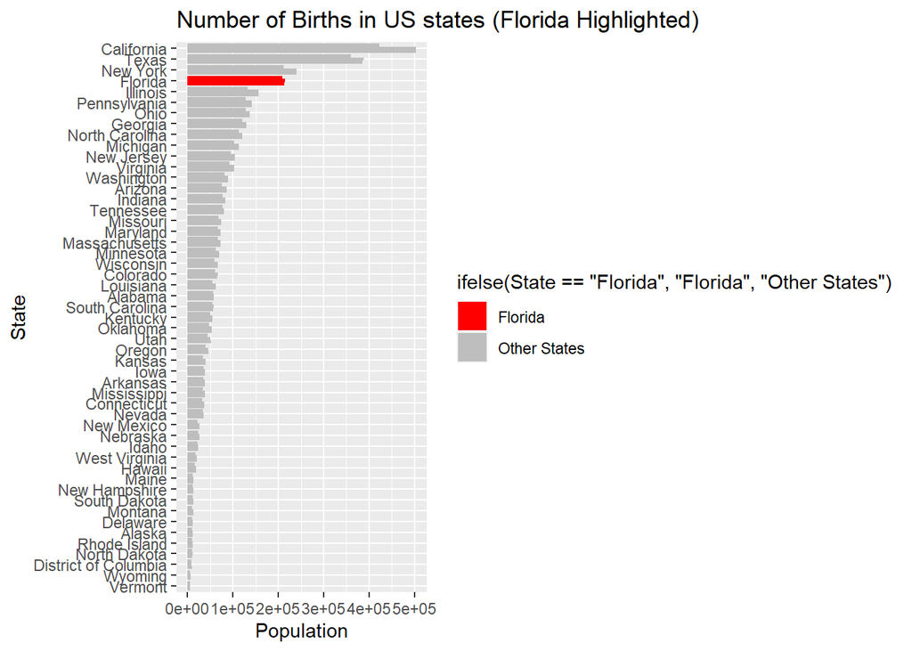

## Q2. Data Munging

I ran an simple evolutionary algorithm (EA) optimization method on five different instances of a binary knapsack problem. Since EAs are stochastic, for each instance I ran 10 independent trials. For each trial and each distinct problem instance, I reported the best solution found (the highest value of items that fit into the knapsack for that problem). You can find this data set at the following location:

knapsack-data.csv

Take this data set compute the mean and standard deviation across all the trials for each problem instance (hint: group_by, summarize), then produce a point and whisker plot where the points position represents the mean and the whisker length represents the standard deviation.

```r
# Loading the required library
library(ggplot2)

# Reading the data
knapsackData <-  read.csv("knapsack-data.csv", header = TRUE, sep = ',')
# summary(knapsackData)
# head(knapsackData)

# Grouping the data
groupName <- group_by(knapsackData, ProblemInstance)
#print(groupName)

# Summarizing the data and computing mean and standard deviation (SD) for each group
summaryKnapsackData <- summarise(groupName, meanResult = mean(BestSolution), sdResult = sd(BestSolution))

# Displaying the mean and sd for each problem instance
print(summaryKnapsackData)
```

```
## # A tibble: 5 × 3
##   ProblemInstance meanResult sdResult
##   <chr>                <dbl>    <dbl>
## 1 P1                    13.9    0.516
## 2 P2                    14.0    0.639
## 3 P3                    13.8    0.467
## 4 P4                    13.5    0.547
## 5 P5                    14.4    0.482
```

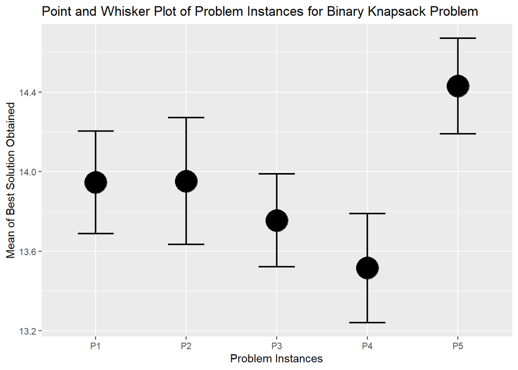

```r
# Plotting the results in point and whisker plot where
# The Points represents the mean and Whisker length represents SD

ggplot(summaryKnapsackData, aes(x=ProblemInstance, y=meanResult)) +
  geom_point(shape = 21, size = 10, fill = "black") +
  geom_errorbar(aes(ymin = meanResult - sdResult/2 , ymax = meanResult + sdResult/2), width=0.4, linewidth = 0.75) +
  xlab("Problem Instances") +
  ylab("Mean of Best Solution Obtained") +
  ggtitle("Point and Whisker Plot of Problem Instances for Binary Knapsack Problem")
```

## Q3. Plot golfers data

Consider the following dataset about PGA golfers in 2004:

pga2004.csv

Find a way to plot the following variables: winnings, and three of the following variables: avedrv, drvacc, grnreg, aveputt, savepct, or events. Explain why you chose those variables and why you chose the encodings your picked for each variable.

Answer: A scatter plot will provide us with an effective visualization for the PGA golfers dataset.

There are various factors (avedrv, drvacc, grnreg, aveputt, savepct, or events) which impacts the performance of the golfers eventually affecting their winnings. I have selected to plot the ‘winnings’ variable against the variables (avedrv, aveputt, and drvacc). These variables which gives average drive distance (avedrv), average putts per round (aveputt), and driving accuracy percentage (drvacc) are essential factors that impact a golfer’s performance affecting winnings. Thus, I have selected these variables.

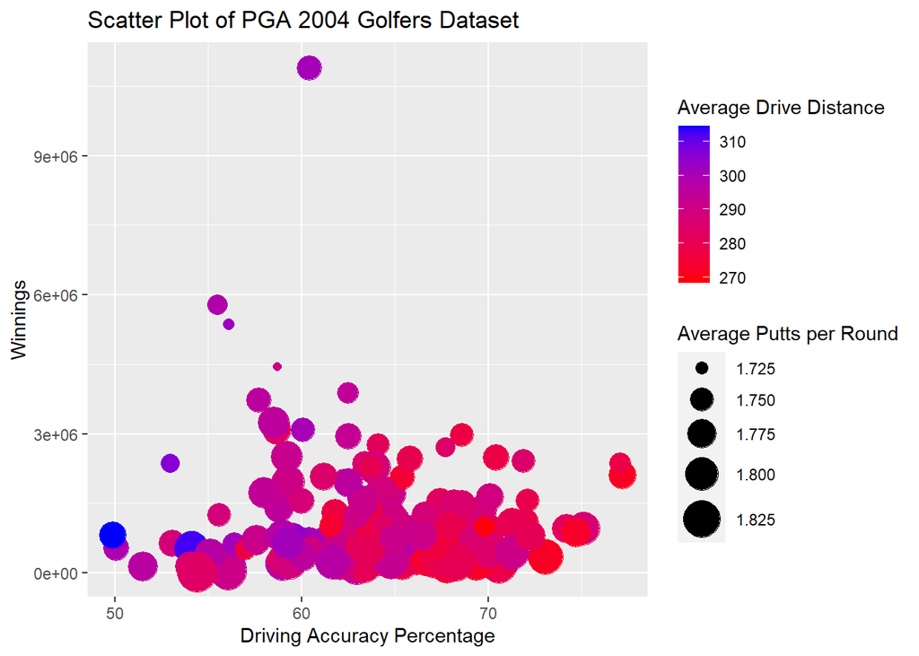

```r
# Loading the required library
library(ggplot2)

# Reading the data
golfersData <-  read.csv("pga2004.csv", header = TRUE, sep = ',')
#summary(golfersData)
#head(golfersData)

# Selecting subset of data corresponding to variables winnings, avedrv, aveputt, drvacc
subsetGolfersData <- golfersData[, c("golfer", "winnings", "avedrv", "aveputt", "drvacc")]
#print(subsetGolfersData)
#head(subsetGolfersData)

# Plotting the winnings against selected variables using Scatter plot
ggplot(subsetGolfersData, aes(x = drvacc, y = winnings, color = avedrv, size = aveputt)) +
  geom_point() +
  scale_color_gradient(low = "red", high = "blue") +
  scale_size_continuous(range = c(2, 10)) +
  labs(x = "Driving Accuracy Percentage",
       y = "Winnings",
       color = "Average Drive Distance",
       size = "Average Putts per Round",
       title = "Scatter Plot of PGA 2004 Golfers Dataset")
```

## Q4. Modeling Data

Consider again the 2004 PGA golfers data from question #3. Construct a standard linear model for predicting the winnings response variable from the following explanatory variables: avedrv, drvacc, grnreg, aveputt, savepct, and events. Construct a second model of some sort for the same variables. Compare these two fits quantitatively and tell which is better.

```r
# R code to construct a standard linear model for predicting the winnings response variable from the following explanatory variables:  avedrv, drvacc, grnreg, aveputt, savepct, and events

# Loading the dataset
golfersData <-  read.csv("pga2004.csv", header = TRUE, sep = ',')
#summary(golfersData)
#head(golfersData)

# Fitting a standard linear model
fitLinearModel <- lm(data = golfersData, formula = (winnings ~ avedrv + drvacc + grnreg + aveputt + savepct + events ))

# Summary of the generated model
summary(fitLinearModel)
```

```
##
## Call:
## lm(formula = (winnings ~ avedrv + drvacc + grnreg + aveputt +
##     savepct + events), data = golfersData)
##
## Residuals:
##      Min       1Q   Median       3Q      Max
## -1491729  -604585  -146672   414106  7437485
##
## Coefficients:
##              Estimate Std. Error t value Pr(>|t|)
## (Intercept)  19505951    7990420   2.441   0.0159 *
## avedrv           3032      15396   0.197   0.8442
## drvacc         -44364      24909  -1.781   0.0771 .
## grnreg         208368      36626   5.689 7.18e-08 ***
## aveputt     -17466478    3741879  -4.668 7.05e-06 ***
## savepct         36835      17063   2.159   0.0326 *
## events         -23031      17817  -1.293   0.1983
## ---
## Signif. codes:  0 '***' 0.001 '**' 0.01 '*' 0.05 '.' 0.1 ' ' 1
##
## Residual standard error: 1012000 on 140 degrees of freedom
## Multiple R-squared:  0.421,  Adjusted R-squared:  0.3962
## F-statistic: 16.97 on 6 and 140 DF,  p-value: 1.15e-14
```

```r
# R code to construct a standard linear model and a generalised linear model  for predicting the winnings response variable from the following explanatory variables:  avedrv, drvacc, grnreg, aveputt, savepct, and events

# Loading the dataset
golfersData <-  read.csv("pga2004.csv", header = TRUE, sep = ',')
#summary(golfersData)
#head(golfersData)

# Fitting a standard linear model
fitLinearModel <- lm(data = golfersData, formula = (winnings ~ avedrv + drvacc + grnreg + aveputt + savepct + events ))

# Fitting a generalised linear model
generalisedLinearModel <- glm(data = golfersData, formula = (winnings ~ avedrv + drvacc + grnreg + aveputt + savepct + events ), family = Gamma(link="inverse"))

# Summary of the generated model
summary(fitLinearModel)
```

```
##
## Call:
## lm(formula = (winnings ~ avedrv + drvacc + grnreg + aveputt +
##     savepct + events), data = golfersData)
##
## Residuals:
##      Min       1Q   Median       3Q      Max
## -1491729  -604585  -146672   414106  7437485
##
## Coefficients:
##              Estimate Std. Error t value Pr(>|t|)
## (Intercept)  19505951    7990420   2.441   0.0159 *
## avedrv           3032      15396   0.197   0.8442
## drvacc         -44364      24909  -1.781   0.0771 .
## grnreg         208368      36626   5.689 7.18e-08 ***
## aveputt     -17466478    3741879  -4.668 7.05e-06 ***
## savepct         36835      17063   2.159   0.0326 *
## events         -23031      17817  -1.293   0.1983
## ---
## Signif. codes:  0 '***' 0.001 '**' 0.01 '*' 0.05 '.' 0.1 ' ' 1
##
## Residual standard error: 1012000 on 140 degrees of freedom
## Multiple R-squared:  0.421,  Adjusted R-squared:  0.3962
## F-statistic: 16.97 on 6 and 140 DF,  p-value: 1.15e-14
```

```r
summary(generalisedLinearModel)
```

```
##
## Call:
## glm(formula = (winnings ~ avedrv + drvacc + grnreg + aveputt +
##     savepct + events), family = Gamma(link = "inverse"), data = golfersData)
##
## Deviance Residuals:
##     Min       1Q   Median       3Q      Max
## -2.0293  -0.6123  -0.1891   0.2691   1.7837
##
## Coefficients:
##               Estimate Std. Error t value Pr(>|t|)
## (Intercept) -1.832e-05  5.048e-06  -3.630 0.000396 ***
## avedrv       6.185e-09  8.555e-09   0.723 0.470918
## drvacc       1.178e-08  1.447e-08   0.814 0.416874
## grnreg      -1.070e-07  1.506e-08  -7.103 5.66e-11 ***
## aveputt      1.346e-05  2.260e-06   5.958 1.97e-08 ***
## savepct     -6.295e-09  1.124e-08  -0.560 0.576507
## events       1.046e-08  7.674e-09   1.363 0.174970
## ---
## Signif. codes:  0 '***' 0.001 '**' 0.01 '*' 0.05 '.' 0.1 ' ' 1
##
## (Dispersion parameter for Gamma family taken to be 0.4956873)
##
##     Null deviance: 131.593  on 146  degrees of freedom
## Residual deviance:  67.892  on 140  degrees of freedom
## AIC: 4309.7
##
## Number of Fisher Scoring iterations: 6
```

```r
# R code to construct a standard linear model and a generalised linear model  for predicting the winnings response variable from the following explanatory variables:  avedrv, drvacc, grnreg, aveputt, savepct, and events and comparing the two generated fitting models quantitatively.

# Loading the dataset
golfersData <-  read.csv("pga2004.csv", header = TRUE, sep = ',')
#summary(golfersData)
#head(golfersData)

# Fitting a standard linear model
fitLinearModel <- lm(data = golfersData, formula = (winnings ~ avedrv + drvacc + grnreg + aveputt + savepct + events ))

# Fitting a generalised linear model
generalisedLinearModel <- glm(data = golfersData, formula = (winnings ~ avedrv + drvacc + grnreg + aveputt + savepct + events ), family = Gamma(link="inverse"))

# Summary of the generated model
#summary(fitLinearModel)
#summary(generalisedLinearModel)

# Computing R-squared value for the standard linear model
rSquareLinearModel <- summary(fitLinearModel)$r.squared

# Computing R-squared value for the generalized linear model
rSquareGeneralisedModel <- summary(generalisedLinearModel)$r.squared

# Computing AIC value for the standard linear model
aicLinearModel <- AIC(fitLinearModel)

# Computing AIC value for the generalized linear model
aicGeneralisedModel <- AIC(generalisedLinearModel)

# Displaying the obtained values
#print(rSquareLinearModel)
#print(rSquareGeneralisedModel)
print("AIC of standard linear model:")
```

```
## [1] "AIC of standard linear model:"
```

```r
print(aicLinearModel)
```

```
## [1] 4491.182
```

```r
print("AIC of generalised linear model:")
```

```
## [1] "AIC of generalised linear model:"
```

```r
print(aicGeneralisedModel)
```

```
## [1] 4309.721
```

The generated models can be compared by computing R-squared and AIC values. A lower value of AIC indicates a better model. From above we obtained the AIC of standard linear model = 4491.182 and AIC of generalised linear model = 4309.721, thus the generalised linear model is a better fit model as the AIC value is low compared to the standard linear model for the above dataset.

## Q5. Predicting from your model

Now consider the following dataset, which consists of three additional golfers not in set on which you made your model fits.

pga2004b.csv

Use your two models from question #4 to make predictions of the winnings in the new data set. Compare these to the actual winnings. Which is the better predictor.

```r
# R code to make predictions of the winnings in the new data set using the standard linear model generated in Q4

# Loading the dataset
golfersData <-  read.csv("pga2004.csv", header = TRUE, sep = ',')
#summary(golfersData)
#head(golfersData)

# Fitting a standard linear model
fitLinearModel <- lm(data = golfersData, formula = (winnings ~ avedrv + drvacc + grnreg + aveputt + savepct + events ))

# Summary of the generated model
#summary(fitLinearModel)

# Loading the new dataset
newGolfersData <-  read.csv("pga2004b.csv", header = TRUE, sep = ',')
#summary(newGolfersData)
#head(newGolfersData)

# Making predictions using the standard linear model
newGolfersData$winnings <- predict(fitLinearModel, newdata = newGolfersData)

# Displaying the result
print(newGolfersData)
```

```
##                      golfer age avedrv drvacc grnreg aveputt savepct mnyrnk
## 1 Vaughn Taylor              28  292.5   65.1   68.4   1.761    41.9     67
## 2 Lee Janzen                 40  286.1   62.2   67.8   1.781    51.5     96
## 3 Guy Boros                  40  281.1   66.3   60.3   1.810    42.5    208
##   events  winnings avewng
## 1     27 1920198.3  43572
## 2     25 1954770.1  33499
## 3     24 -620050.6   5449
```

```r
# Loading the original new dataset
originalNewGolfersData <-  read.csv("pga2004b.csv", header = TRUE, sep = ',')

# Comparing the predicted winnings to real winnings
result = newGolfersData$winnings - originalNewGolfersData$winnings

# Displaying the difference between predicted and real winnings
print(result)
```

```
## [1]  743763.3 1117288.1 -750833.6
```

```r
# Mean squared error for the standard linear model
mseLinearModel <- mean((result)^2)

print(mseLinearModel)
```

```
## [1] 788422587599
```

```r
# R code to make predictions of the winnings in the new data set using the  generalised linear model generated in Q4

# Loading the dataset
golfersData <-  read.csv("pga2004.csv", header = TRUE, sep = ',')
#summary(golfersData)
#head(golfersData)

# Fitting a generalised linear model
generalisedLinearModel <- glm(data = golfersData, formula = (winnings ~ avedrv + drvacc + grnreg + aveputt + savepct + events ), family = Gamma(link="inverse"))

# Summary of the generated model
#summary(generalisedLinearModel)

# Loading the new dataset
newGolfersData <-  read.csv("pga2004b.csv", header = TRUE, sep = ',')
#summary(newGolfersData)
#head(newGolfersData)

# Make predictions using the generalized linear model
newGolfersData$winnings <- predict(generalisedLinearModel, newdata = newGolfersData)

# Displaying the result
print(newGolfersData)
```

```
##                      golfer age avedrv drvacc grnreg aveputt savepct mnyrnk
## 1 Vaughn Taylor              28  292.5   65.1   68.4   1.761    41.9     67
## 2 Lee Janzen                 40  286.1   62.2   67.8   1.781    51.5     96
## 3 Guy Boros                  40  281.1   66.3   60.3   1.810    42.5    208
##   events     winnings avewng
## 1     27 6.586943e-07  43572
## 2     25 8.370456e-07  33499
## 3     24 2.093572e-06   5449
```

```r
# Loading the original new dataset
originalNewGolfersData <-  read.csv("pga2004b.csv", header = TRUE, sep = ',')

# Comparing the predicted winnings to real winnings
result = newGolfersData$winnings - originalNewGolfersData$winnings

# Displaying the difference between predicted and real winnings
print(result)
```

```
## [1] -1176435  -837482  -130783
```

```r
# Mean squared error for the generalised linear model
mseGeneralisedModel <- mean((result)^2)

print(mseGeneralisedModel)
```

```
## [1] 700826534212
```